# Building Capacity for Data-Driven Urban Mobility

Keynote for the ITF-Eurostat Conference on Promoting Data-Driven Decision-Making

Professor Robin Lovelace

r.lovelace@leeds.ac.uk

Institute for Transport Studies, University of Leeds

November 4, 2025

## Introduction

- **Who am I?** Professor of Transport Data Science at the University of Leeds.
- **My focus:** Building open, reproducible, and policy-relevant transport planning tools.
- **Today’s topic:** Building *capacity* for data-driven decision-making in urban mobility.
- **Why it matters for Southeast Europe:** Supporting sustainable mobility goals and the path to EU collaboration.

## Context: Southeast Europe

[figure not shown]

## The Challenge: The Data-to-Policy Gap

We have more data than ever before, but are we using it effectively?

**Common Barriers:**

- **Data Access:** Data is often siloed, proprietary, or not in a usable format.
- **Skills & Tools:** Lack of training and accessible tools to analyse the data.
- **Institutional Culture:** Resistance to new methods and a disconnect between analysts and decision-makers.
- **Procurement:** Over-reliance on ‘black box’ commercial solutions.

## A Solution: Open & Reproducible Workflows

Openness builds trust and empowers collaboration.

- **Open Source:** The code is free to use, modify, and share.
- **Open Data:** Public data is accessible to everyone.
- **Open Methods:** Methodologies are transparent and documented.
- **Open Access:** Research and educational materials are freely available.
- **Community of Practice**.

[figure not shown]

Source: Lovelace, Parkin, and Cohen (2020)

## Open science for researchers

1. Open access to the publications
2. Open access to sample (synthetic if sensitive) data
3. Open access to the code
4. Fully reproducible paper published with documentation
5. Project deployed in tool for non-specialist use

Source: Braga et al. (2023)

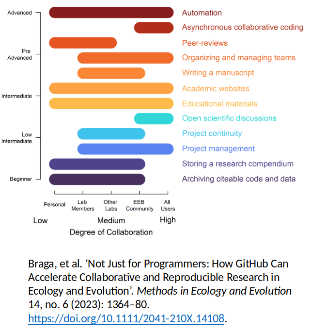

## Example community of practice: QGIS

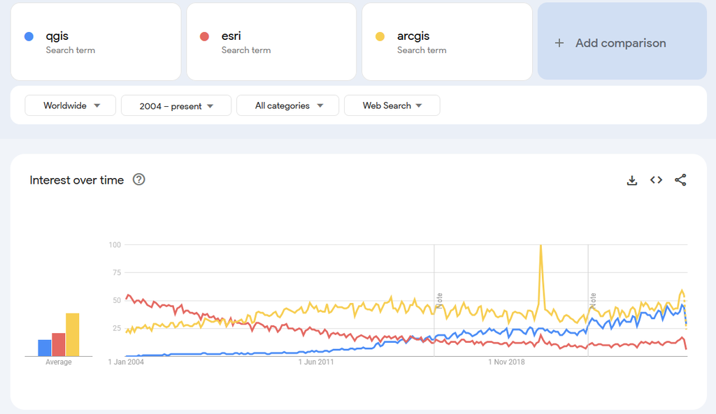

## Why is QGIS so strong?

[figure not shown]

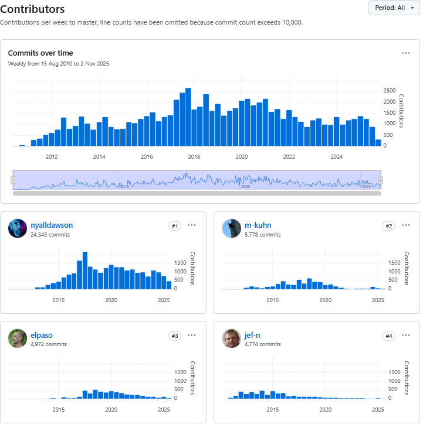

## Aside: Geographic distribution of QGIS interest

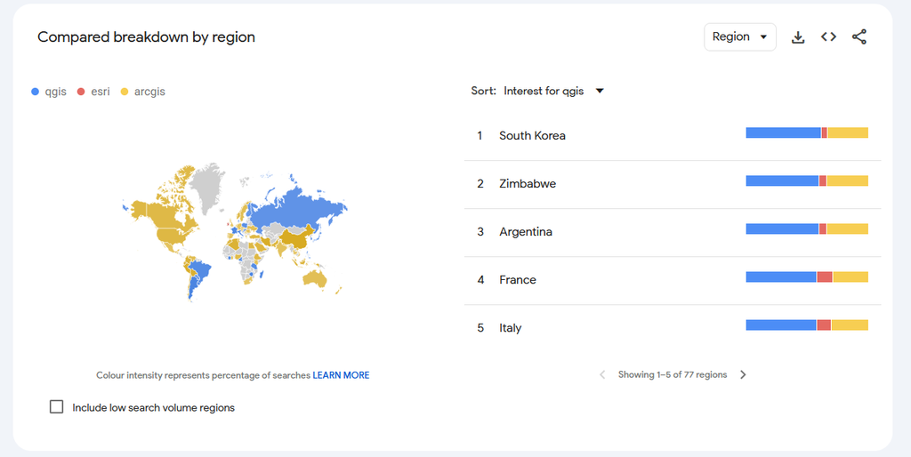

## Pillar 1: Open Data & Standards

Good analysis starts with good data.

- **Data Standards are Key:**
  - GTFS for public transport schedules.
  - GBFS for shared micro-mobility (bikes, scooters).
  - OpenStreetMap for detailed street network data.
- **National Data Portals:** A vital resource for official statistics and geographic data.
- **Example:** Sourcing road network data from OpenStreetMap for a whole country.

## Pillar 2: Open Source Tools

Powerful, free, and adaptable tools for transport analysis.

- **The R & Python Ecosystems:** Mature, extensive libraries for data science, statistics, and visualisation.
- **Example (R):** The `stplanr` package for transport planning and modelling.
- **Example (Python):** `geopandas` and `pandana` for network analysis.
- These tools can be adapted to local needs and data sources.

[figure not shown]

## Pillar 3: Communities of Practice

Capacity building is not just about tools, it’s about people.

- A ‘Community of Practice’ is a group of people who “share a concern or a passion for something they do and learn how to do it better as they interact regularly” (Wenger 1998).
- Open source projects naturally foster these communities.
- Examples: rOpenSci, rOpenSpain, QGIS user groups.
- They provide support, share best practices, and drive innovation.
- **Key takeaway:** To build capacity, invest in building communities.

## Case Study 1: National-Scale Planning (UK)

From local data to national strategy with `plan.activetravelengland.gov.uk`.

- **Purpose:** Prioritise billions of £ in investment for walking and cycling.
- **How it works:**
  - Integrates dozens of open datasets (e.g., census, road safety, network data).
  - Uses a transparent, open-source model (`pct` R package).
  - Provides a web interface for planners across the country.
- **Impact:** A consistent, evidence-based approach to national transport planning.

## Active Travel England Tool: plan.activetravelengland.gov.uk

[figure not shown]

## Case Study 2: Regional Planning (Scotland)

The Network Planning Tool (npt.scot).

- **Purpose:** Help regional and local authorities design and prioritise active travel networks.
- **Features:**
  - Open data and transparent methods.
  - Estimates of cycling potential and Level of Service.
  - Web UI for planners and the public.
- **Lesson:** A powerful tool can be developed and deployed for a specific region, and can serve as a model for others.

## Network Planning Tool for Scotland: npt.scot

[figure not shown]

## Case Study 3: National OD data in Spain

- The `spanishoddata` package provides access to Spain’s national origin-destination mobility survey.
- It’s a community-driven project, adopted by **rOpenSpain**, ensuring long-term maintenance and quality.
- The tool is used by researchers and public bodies, including the **Spanish Ministry of Transport**, for evidence-based planning.
- This demonstrates a successful model of collaboration between government, academia, and the open-source community.

## Mobility analysis with `spanishoddata`

[figure not shown]

## Making it Happen in Southeast Europe

How can you apply these principles?

1. **Start with a Data Audit:** What data do you have? What format is it in? What can be opened?
2. **Run a Pilot Project:** Choose a specific problem (e.g., mapping cycling potential in one city) and solve it with open tools.
3. **Invest in Training:** Build skills in R or Python for spatial data analysis within your statistical offices and transport authorities.
4. **Foster Regional Collaboration:** Share data, code, and experiences with neighbouring countries facing similar challenges.

## Future Directions: New Data & New Challenges

The landscape is always changing.

- **New Data Sources:** Mobile phone data, GPS tracks, sensor data offer huge potential.
  - Companies can be paid or mandated to share anonymised data for public good, e.g. mobile network operators.
- **New Challenges:**
  - **Quality & Bias:** Are these new datasets representative?
  - **Privacy & Ethics:** How do we use sensitive data responsibly?
  - **Governance:** Who owns the data and the insights?
- **New tools** provide new ways to add value to existing datasets

## Jittering Method for Privacy Preservation

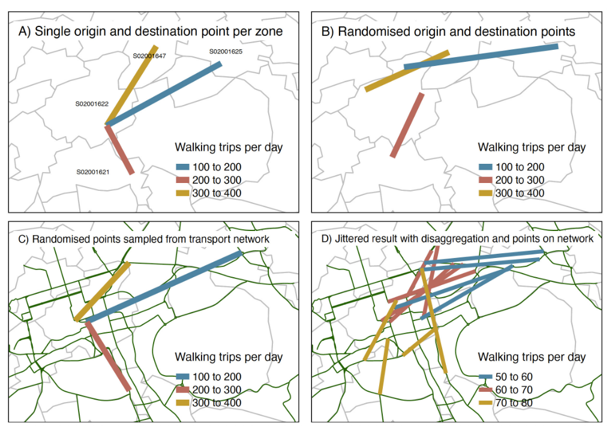

## Demo: Mapping Southeast Europe with Open Tools

Results created with the `eurostat` and `giscoR` packages to download and map official geospatial data for the region (see code on [GitHub](https://github.com/Robinlovelace/presentations/blob/f1a2149d8319b13f9baed4beb3ba6ad9556da00a/itf2025.qmd#L307-L357))

[figure not shown]

Southeast Europe Map

# Thank you

- **Key message:** Sustainable capacity is built on **open data, open tools, and an open community.**
- Slides and code: `github.com/robinlovelace/presentations`
- Contact: `r.lovelace@leeds.ac.uk`

## References

Braga, Pedro Henrique Pereira, Katherine Hébert, Emma J Hudgins, Eric R Scott, Brandon PM Edwards, Luna L Sanchez Reyes, Matthew J Grainger, et al. 2023. “Not Just for Programmers: How GitHub Can Accelerate Collaborative and Reproducible Research in Ecology and Evolution.” *Methods in Ecology and Evolution* 14 (6): 1364–80.

Kotov, Egor, Robin Lovelace, and Eugeni Vidal-Tortosa. 2024. *Spanishoddata*. https://doi.org/10.32614/CRAN.package.spanishoddata.

Lovelace, Robin, John Parkin, and Tom Cohen. 2020. “Open Access Transport Models: A Leverage Point in Sustainable Transport Planning.” *Transport Policy* 97 (October): 47–54. https://doi.org/10.1016/j.tranpol.2020.06.015.

Wenger, Etienne. 1998. *Communities of Practice: Learning, Meaning, and Identity*. Cambridge University Press.